# ayush5

**Computer Vision**

**Name: Honey Singh**

**Enrollment No: 12419051622**

**Lab - 5 :** Harris Corner Detection

# **OBJECTIVE**

To detect and visualize the corners (i.e., interest points or feature points) in an image using the Harris Corner Detection algorithm

# Harris Corner Detection

A corner is where two edges intersect, representing a significant change in image brightness in multiple directions. These interest points are important image features.

**SSD (Sum of Squared Differences)** quantifies how much a window changes when shifted, helping detect unique regions.

**Structure Tensor (Matrix M)** simplifies analysis using image gradients, where:

- M contains second-moment derivatives (Ixx, Iyy, Ixy)
- Corner response: R = det(M) - k * (trace(M))²
- det(M) = λ₁λ₂ and trace(M) = λ₁+λ₂

**Classification based on eigenvalues:**

- Small λ₁,λ₂: flat region (small |R|)
- One large, one small λ: edge (R < 0)
- Both large λ₁≈λ₂: corner (large R)

The algorithm analyzes local windows around each pixel to find points that show significant intensity changes in all directions.

```python
import numpy as np
import pandas as pd
import matplotlib.pyplot as plt
import cv2
```

# **Reading and Displaying Image**

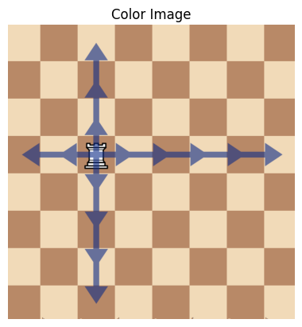

[figure not shown]

```python
img = cv2.imread(r"H:\My Drive\U.S.A.R\6th Semester\Lab\rook-moves-1.png")
img_rgb = cv2.cvtColor(img, cv2.COLOR_BGR2RGB)
img_gray = cv2.cvtColor(img, cv2.COLOR_BGR2GRAY)
img_gray = np.float32(img_gray)

plt.imshow(img_rgb)
plt.axis("off")
plt.title("Color Image")
plt.show()

plt.imshow(img_gray, cmap='gray')
plt.axis("off")
plt.title("Grayscale Image")
plt.show()
```

# **Image Gradients with Sobel Filters**

To measure changes in intensity in x and y directions, i.e., gradients.

This tells us where the image is changing rapidly – possible edges or corners.

```python
sobel_y=np.array([[-1,-2,-1],[0,0,0],[1,2,1]])
sobel_x=sobel_y.T
print("sobel_x")
print(sobel_x)

print("sobel_y")
print(sobel_y)
```

```
sobel_x
[[-1  0  1]
 [-2  0  2]
 [-1  0  1]]
sobel_y
[[-1 -2 -1]
 [ 0  0  0]
 [ 1  2  1]]
```

```python
Ix=cv2.filter2D(img_gray,-1,sobel_x)
Iy=cv2.filter2D(img_gray,-1,sobel_y)
```

# **Computing Structure Tensor (Matrix M)**

We apply Gaussian blur to smooth the values and suppress noise in local neighborhood.

```python
Ixx=cv2.GaussianBlur(Ix*Ix,(3,3),1)
Iyy=cv2.GaussianBlur(Iy*Iy,(3,3),1)
Ixy=cv2.GaussianBlur(Ix*Iy,(3,3),1)
```

# **Harris Corner Detection**

Harris Corner Detection is an algorithm used in computer vision to find corners (also called interest points) in an image.

We analyze a small window (usually 3×3 or 5×5) around each pixel.

1. In flat regions, there's no gradient change in any direction — shifting the window makes no difference.
2. Along an edge, changes are visible only in one direction — not distinctive.
3. In a corner, shifting the window in any direction causes significant change — highly distinctive

**`Harris Response`**

It is a score calculated for each pixel to decide if it’s a corner, edge, or flat region. The three formulae utilized are -

1. R = detM-k*(traceM)
2. R = detM / traceM
3. R = λ1

**Function: harris_corner()**

This function marks the corners detected in the image using the Harris response matrix by coloring them red.

**Steps:**

1. Create a copy of the image
2. Iterating over each pixel in the Harris response matrix. If the response r is greater than a threshold mark it red.
3. Display the result.

```python
detM=Ixx*Iyy-(Ixy)**2
traceM=Ixx+Iyy
# Calculating lamda
sqrt_term = np.sqrt((traceM ** 2) - 4 * detM)
lambda1 = (traceM + sqrt_term) / 2
```

```python
def harris_corner(image, harris_response):
    # Copy image for marking corners
    img_corners_only = np.copy(image)

    # Highlight only the corners
    for row_index, response in enumerate(harris_response):
        for col_index, r in enumerate(response):
            if r > 100:
                img_corners_only[row_index, col_index] = [255, 0, 0]  # Red

    # Plot
    plt.figure(figsize=(8, 8))
    plt.title("Corners Found (Only)")
    plt.imshow(img_corners_only)
    plt.axis("off")
    plt.show()
```

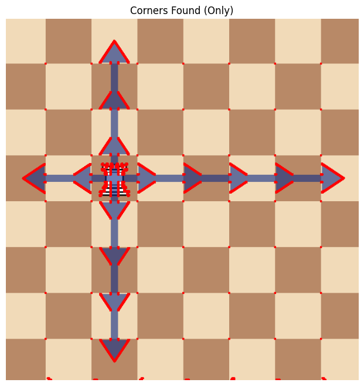

```python
k=0.05
harris_response=detM-k*(traceM)
harris_corner(img_rgb, harris_response)
```

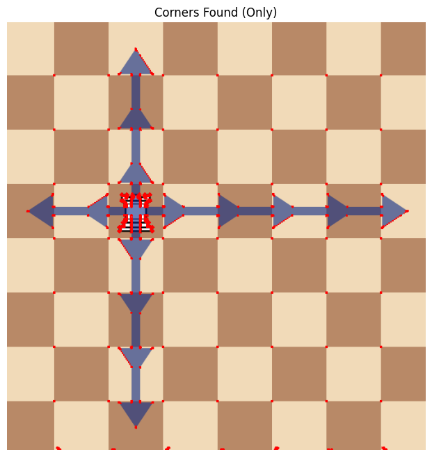

```python
harris_response = detM / traceM
harris_corner(img_rgb, harris_response)
```

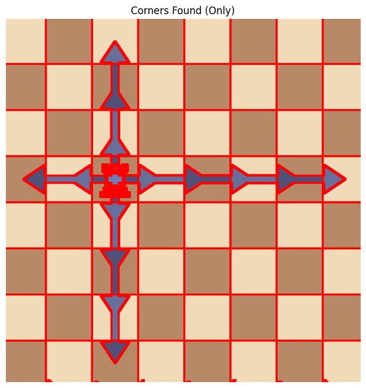

```python
harris_response= lambda1
harris_corner(img_rgb, harris_response)
```

# **Conclusion**

Harris Corner Detection is a simple yet powerful technique to identify interest points in an image. With just a few lines of code, you can visualize and understand the structure hidden within images.